# Federalist Multinomial / Vectors

Petro Tolochko

# Preparation

### Required Packages

We first need to install the packages required for further analysis.

```r
# install.packages("tm")                            # probably already installed
# install.packages("tidyverse")                     # probably already installed
# install.packages("ggthemes") # for nicer graphics # new
# install.packages("ggrepel")
# install.packages("cowplot")
# install.packages("SnowballC")
```

Note: you only need to install the packages once.

We then need load the packages in our environment:

```r
library(tm)
library(tidyverse)
library(openNLP)
library(SnowballC)
library(ggthemes)
library(ggrepel)
```

Check if your working directory is the correct one:

```r
getwd()
```

```
## [1] "/Users/petrotolochko/Desktop/Teaching/CEU_text_analysis_25/meeting_3"
```

```r
setwd("~/Desktop/Teaching/CEU_text_analysis_25/meeting_3/") # this is an example, paste your path here
```

Ok, now read in the file `federalist.csv` and inspect:

```r
federalist <- read_csv("federalist.csv")
federalist
```

```
## # A tibble: 85 × 6
##    author   text                                      date  title paper_id venue
##    <chr>    <chr>                                     <chr> <chr>    <dbl> <chr>
##  1 HAMILTON "To the People of the State of New York:… <NA>  Gene…        1 For …
##  2 JAY      "To the People of the State of New York:… <NA>  Conc…        2 For …
##  3 JAY      "To the People of the State of New York:… <NA>  The …        3 For …
##  4 JAY      "To the People of the State of New York:… <NA>  The …        4 For …
##  5 JAY      "To the People of the State of New York:… <NA>  The …        5 For …
##  6 HAMILTON "To the People of the State of New York:… <NA>  Conc…        6 For …
##  7 HAMILTON "To the People of the State of New York:… <NA>  The …        7 For …
##  8 HAMILTON "To the People of the State of New York:… Tues… The …        8 From…
##  9 HAMILTON "To the People of the State of New York:… <NA>  The …        9 For …
## 10 MADISON  "To the People of the State of New York:… Frid… The …       10 From…
## # ℹ 75 more rows
```

```r
names(federalist)
```

```
## [1] "author"   "text"     "date"     "title"    "paper_id" "venue"
```

Let’s see how a text looks like:

```r
federalist$text[1] # explain this!
```

```
## [1] "To the People of the State of New York:\n\nAFTER an unequivocal experience of the inefficacy of the\nsubsisting federal government, you are called upon to deliberate on\na new Constitution for the United States of America. The subject\nspeaks its own importance; comprehending in its conseque…
```

Amazing, let’s continue.

### Basic Pre-processing

```r
clean_federalist <- federalist %>%
  mutate(                           # the mutate() function is part of dplyr package / allows to change stuff within the dataframe easily
    text   = str_to_lower(text),                # turn all letters to lowercase
    text   = str_replace_all(text, "\n", " "),  # replace '/n' carriage return symbols
    text   = str_remove_all(text, "[:punct:]"), # remove all punctuation
    man    = str_count(text, "\\Wman "),        # Basic regex (more about it later in the course. '\\W' part means at the begging of the word) and count those up
    by     = str_count(text, "\\Wby "),         # same
    upon   = str_count(text, "\\Wupon ")        # same
  ) %>%
  rowwise() %>%                                 # make future functions work rowwise
  mutate(
    length = length(str_split(text, " ")[[1]])  # calculate the length of the text (in words)
  )
```

How does it look like now?

```r
clean_federalist$text[1]
```

```
## [1] "to the people of the state of new york  after an unequivocal experience of the inefficacy of the subsisting federal government you are called upon to deliberate on a new constitution for the united states of america the subject speaks its own importance comprehending in its consequences noth…
```

Nice! Did the word counting work?

```r
clean_federalist %>%
  select(man, by, upon)
```

```
## # A tibble: 85 × 3
## # Rowwise:
##      man    by  upon
##    <int> <int> <int>
##  1     0    14     6
##  2     0    10     1
##  3     0    18     0
##  4     0    14     0
##  5     0    10     0
##  6     2    11     4
##  7     0    28    11
##  8     2    11     3
##  9     1    13     4
## 10     3    39     0
## # ℹ 75 more rows
```

Looks like it! Now we’re ready for some real analysis.

# Federalist Analysis [Simplified from (Grimmer at al., 2022)]

### Multinomial Model!

We’ll do something else later, I promise.

Let’s calculate the word rates for Hamilton, Madison, and Jay. Call them $\mu_{h}$, $\mu_{m}$, and $\mu_{j}$:

```r
mu_madison <- clean_federalist %>%
  filter(author == "MADISON") %>%
  select(man, by, upon) %>%
  colSums()

mu_hamilton <- clean_federalist %>%
  filter(author == "HAMILTON") %>%
  select(man, by, upon) %>%
  colSums()

mu_jay <- clean_federalist %>%
  filter(author == "JAY") %>%
  select(man, by, upon) %>%
  colSums()
```

Check them:

```r
mu_madison; mu_hamilton; mu_jay
```

```
##  man   by upon
##   17  474    7
```

```
##  man   by upon
##  102  859  374
```

```
##  man   by upon
##    0   82    1
```

Now, calculate their probabilities and call them $\hat{\mu}_{h}$, $\hat{\mu}_{m}$, and $\hat{\mu}_{j}$:

```r
mu_hat_hamilton <- mu_hamilton / sum(mu_hamilton)
mu_hat_madison <- mu_madison / sum(mu_madison)
mu_hat_jay <- mu_jay / sum(mu_jay)
```

These are their word models! We’re almost there… Now, the Federalist paper *#49* is one of the disputed ones. First, let’s see it:

```r
clean_federalist$text[49]
```

```
## [1] "to the people of the state of new york  the author of the notes on the state of virginia quoted in the last paper has subjoined to that valuable work the draught of a constitution which had been prepared in order to be laid before a convention expected to be called in 1783 by the legislature…
```

```r
clean_federalist[49, ]
```

```
## # A tibble: 1 × 10
## # Rowwise:
##   author              text   date  title paper_id venue   man    by  upon length
##   <chr>               <chr>  <chr> <chr>    <dbl> <chr> <int> <int> <int>  <int>
## 1 HAMILTON OR MADISON "to t… Tues… Meth…       49 From…     2    15     0   1657
```

```r
### Disputed ###
mu_disputed <- clean_federalist[49, ] %>%
  select(man, by, upon)

mu_disputed
```

```
## # A tibble: 1 × 3
## # Rowwise:
##     man    by  upon
##   <int> <int> <int>
## 1     2    15     0
```

Calculating probabilities… There’s a built-in `dmultinom` function! You can check what it’s doing by typing `?dmultinom` in your console.

```r
p_disputed_hamilton <- dmultinom(mu_disputed,
                                 prob = mu_hat_hamilton)
p_disputed_madison  <- dmultinom(mu_disputed,
                                 prob = mu_hat_madison)
p_disputed_jay      <- dmultinom(mu_disputed,
                                 prob = mu_hat_jay)
```

And done!

```r
p_disputed_hamilton; p_disputed_madison; p_disputed_jay
```

```
## [1] 0.001065259
```

```
## [1] 0.07554627
```

```
## [1] 0
```

As *Individual Work*: try all the words (not just the ones we used here) and see if you get better or worse results. Play around with *Laplace smoothing* – i.e., adding a small number to the model to eliminate 0 probability words (e.g., add `1` to all counts before calculating probability).

# Vector Space Model

Let’s look at the Federalist papers as vectors. Just the selected words for now (so, in the `man`, `by`, `upon` vector space). We already have them as vector representations:

```r
mu_madison; mu_hamilton; mu_jay
```

```
##  man   by upon
##   17  474    7
```

```
##  man   by upon
##  102  859  374
```

```
##  man   by upon
##    0   82    1
```

We can try to visualize them. A bit difficult to do 3D (although possible), so let’s try to visualize them in 2D.

First, we need to play around with data a bit, for visualization.

```r
vector_visualizations <- rbind(mu_madison, mu_hamilton, mu_jay, mu_disputed)

vector_visualizations$author = c("Madison", "Hamilton", "Jay", "Disputed")
```

Lets remove the `man` dimension for the visualization:

```r
vector_visualizations_no_man <- vector_visualizations %>%
  select(-man)

vector_visualizations_no_man
```

```
## # A tibble: 4 × 3
## # Rowwise:
##      by  upon author
##   <dbl> <dbl> <chr>
## 1   474     7 Madison
## 2   859   374 Hamilton
## 3    82     1 Jay
## 4    15     0 Disputed
```

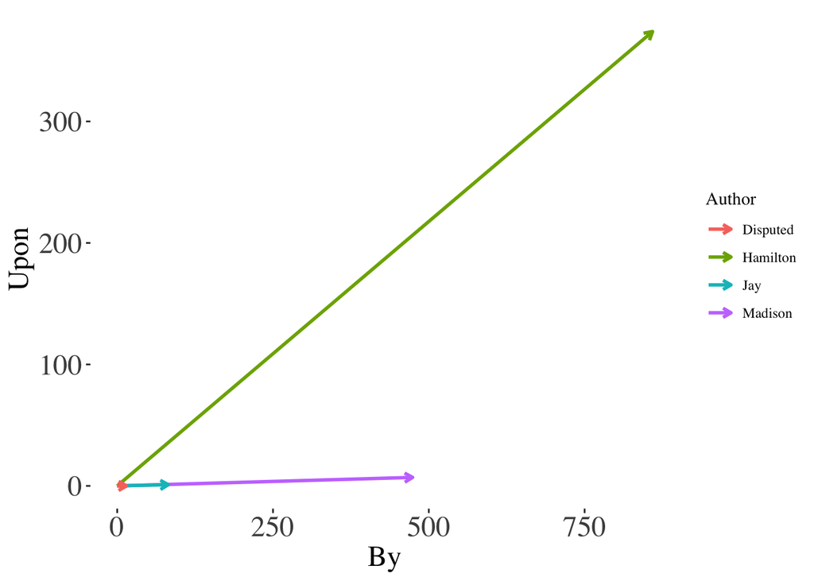

```r
vector_visualizations_no_man %>%
  ggplot() +
  geom_segment(aes(x = 0, y = 0, xend = by, yend = upon, color = factor(author)),
               arrow = arrow(length = unit(0.2,"cm")),
               size = 1) +
  theme_tufte() +
  theme(
    # legend.position = "none",

    axis.title.x = element_text(size = 18),
    axis.title.y = element_text(size = 18),
    axis.text.x = element_text(size = 18),
    axis.text.y = element_text(size = 18)
  ) +
  xlab("By") +
  ylab("Upon") +
  labs(color = 'Author')
```

Ok, not very helpful, let’s try removing `by` dimension…

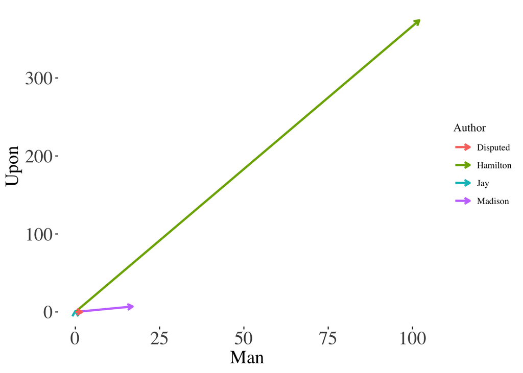

```r
vector_visualizations_no_by <- vector_visualizations %>%
  select(-by)

vector_visualizations_no_by %>%
  ggplot() +
  geom_segment(aes(x = 0, y = 0, xend = man, yend = upon, color = factor(author)),
               arrow = arrow(length = unit(0.2,"cm")),
               size = 1) +
  theme_tufte() +
  theme(
    # legend.position = "none",

    axis.title.x = element_text(size = 18),
    axis.title.y = element_text(size = 18),
    axis.text.x = element_text(size = 18),
    axis.text.y = element_text(size = 18)
  ) +
  xlab("Man") +
  ylab("Upon") +
  labs(color = 'Author')
```

Let’s increase the vector magnitude for the `Disputed` vector. And maybe the `Jay` vector. Just to see it better:

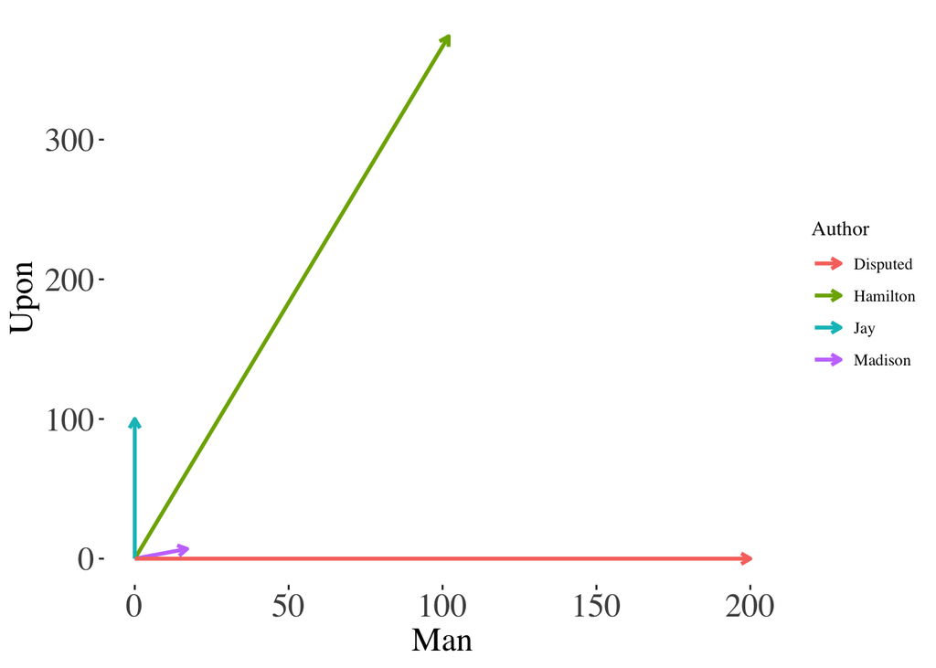

```r
vector_visualizations_no_by[4, 1:2] <- vector_visualizations_no_by[4, 1:2] * 100
vector_visualizations_no_by[3, 1:2] <- vector_visualizations_no_by[3, 1:2] * 100
vector_visualizations_no_by %>%
  ggplot() +
  geom_segment(aes(x = 0, y = 0, xend = man, yend = upon, color = factor(author)),
               arrow = arrow(length = unit(0.2,"cm")),
               size = 1) +
  theme_tufte() +
  theme(
    # legend.position = "none",

    axis.title.x = element_text(size = 18),
    axis.title.y = element_text(size = 18),
    axis.text.x = element_text(size = 18),
    axis.text.y = element_text(size = 18)
  ) +
  xlab("Man") +
  ylab("Upon") +
  labs(color = 'Author')
```

So, just visually (on the dimensions `upon` and `man`), the `Disputed` paper has the smallest angle compared to `Madison`.

## Cosine similarity

Cosine similarity is *!!! SURPRISE SURPRISE !!!* a **similarity** measure between two vectors.

It is defined as:

$$cos(\theta) = \frac{\mathbf{A} \cdot \mathbf{B}}{||\mathbf{A}||
||\mathbf{B}||}$$

Where $\mathbf{A} \cdot \mathbf{B} = A_1 \times B_1 + A_2 \times B_2 ...$ is the dot product of vectors, `%*%` operator in `r`. And $||A||$ is the **magnitude** (or, **Eucledian Norm**) of the vector – $\sqrt{\Sigma^b_{i = 1}A^2_i}$.

$$cos(\theta) = \frac{\mathbf{A} \cdot \mathbf{B}}{||\mathbf{A}||
||\mathbf{B}||} = \frac{\Sigma^b_{i=1}A_iB_i}{\sqrt{\Sigma^b_{i =
1}A^2_i}\sqrt{\Sigma^b_{i = 1}B^2_i}}$$

We can write the function:

```r
cosine_sim <- function(A, B) {
  numerator   <- A %*% B
  denominator <- sqrt(sum(A^2)) * sqrt(sum(B^2))

  similiarity <- numerator / denominator
  return(similiarity)
}
```

Let’s get the data for analysis:

```r
vectors <- vector_visualizations[, 1:3] %>% as.matrix()
```

And now, let’s calculate the similarity between them.

```r
similarity_matrix <- matrix(
  nrow = 4, ncol = 4
)

for (i in 1:nrow(similarity_matrix)) {
  for (j in 1:ncol(similarity_matrix)) {
    similarity_matrix[i, j] = cosine_sim(vectors[i, ], vectors[j, ])
  }
}

rownames(similarity_matrix) <- vector_visualizations$author
colnames(similarity_matrix) <- vector_visualizations$author

similarity_matrix
```

```
##            Madison  Hamilton       Jay  Disputed
## Madison  1.0000000 0.9205306 0.9993543 0.9952196
## Hamilton 0.9205306 1.0000000 0.9162519 0.9177891
## Jay      0.9993543 0.9162519 1.0000000 0.9911542
## Disputed 0.9952196 0.9177891 0.9911542 1.0000000
```

Once again, for *NO ADDITIONAL POINTS* calculate the similarity between `Madison`, `Hamilton` and all other disputed papers (one by one). We can check which ones are disputed:

```r
clean_federalist %>%
  filter(author == "HAMILTON OR MADISON")
```

```
## # A tibble: 11 × 10
## # Rowwise:
##    author              text  date  title paper_id venue   man    by  upon length
##    <chr>               <chr> <chr> <chr>    <dbl> <chr> <int> <int> <int>  <int>
##  1 HAMILTON OR MADISON "to … Tues… Meth…       49 From…     2    15     0   1657
##  2 HAMILTON OR MADISON "to … Tues… Peri…       50 From…     0    11     1   1115
##  3 HAMILTON OR MADISON "to … Frid… The …       51 From…     1    23     0   1924
##  4 HAMILTON OR MADISON "to … Frid… The …       52 From…     0    22     0   1855
##  5 HAMILTON OR MADISON "to … Tues… The …       53 From…     2    31     0   2215
##  6 HAMILTON OR MADISON "to … Tues… The …       54 From…     1    26     2   2018
##  7 HAMILTON OR MADISON "to … Frid… The …       55 From…     0    14     0   2088
##  8 HAMILTON OR MADISON "to … Tues… The …       56 From…     0    10     0   1580
##  9 HAMILTON OR MADISON "to … Tues… The …       57 From…     2    25     0   2216
## 10 HAMILTON OR MADISON "to … <NA>  The …       62 For …     1    28     0   2412
## 11 HAMILTON OR MADISON "to … <NA>  The …       63 For …     2    51     0   3066
```

# Bonus!

3D vector visualization:

```r
# install.packages("rgl")
# library(rgl)
#
#
#
# # Define your vectors
# vector_madison <- c(17, 474, 7)
# vector_hamilton <- c(102, 859, 374)
# vector_jay <- c(0, 82, 1)
#
# # Create a 3D plot
# open3d()
# plot3d(0, 0, 0, type = "n", xlim = c(-3, 3), ylim = c(-3, 3), zlim = c(-3, 3), main = "3-Word Space")
#
#
#
# # Add vectors to the plot
# arrow3d(p0 = c(0, 0, 0), p1 = c(vector_madison[1], vector_madison[2], vector_madison[3]), col = "indianred", length = 0.1)
# arrow3d(p0 = c(0, 0, 0), p1 = c(vector_hamilton[1], vector_hamilton[2], vector_hamilton[3]), col = "steelblue", length = 0.1)
# arrow3d(p0 = c(0, 0, 0), p1 = c(vector_jay[1], vector_jay[2], vector_jay[3]), col = "gold", length = 0.1)
#
#
# # Add labels to the vectors
# text3d(vector_madison[1], vector_madison[2], vector_madison[3], texts = "Madison", adj = 0)
# text3d(vector_hamilton[1], vector_hamilton[2], vector2[3], vector_hamilton = "Hamilton", adj = 0)
# text3d(vector_jay[1], vector_jay[2], vector_jay[3], texts = "Jay", adj = 0)
```